# Expected Pressure: An evaluation of individual and team performances in pressing situations

2025-07-16

# Introduction

Here, we are analyzing pressing sequences in soccer to predict whether they will result in a forced turnover within 5 seconds after the pressing sequence starts. Let’s start by loading our data and doing some basic preprocessing.

## Libraries

```r
library(tidyverse)
library(data.table)
library(tidymodels)
library(stacks)
library(xgboost)
library(caret)
library(glmnet)
library(tictoc)
theme_set(theme_light())
```

## Data Loading and Preparation

Our dataset contains pressing sequences from 10 MLS matches in the 2023 season. Each row represents a pressing sequence with various spatio-temporal variables.

```r
pressing_data <- read_csv("results/all_games_pressing_sequences.csv") |>
  select(-match_id:-player_in_possession_name, -game_id) |>
  mutate_if(is.character, as.factor) |>
  mutate_if(is.logical, as.factor) |>
  as.data.table()

# exclude pressing sequence that last just 1 frame (0.1s), could be noise
# pressing_data <- pressing_data[sequence_duration_frames > 1]
```

View data structure

```r
# head(pressing_data)
glimpse(pressing_data)
```

```
## Rows: 4,875
## Columns: 27
## $ period                          <dbl> 1, 1, 1, 1, 1, 1, 1, 1, 1, 1, 1, 1, 1,…
## $ ball_carrier_x                  <dbl> 26.28, 29.06, 34.98, -32.39, -48.07, -…
## $ ball_carrier_y                  <dbl> -28.15, -4.01, 11.74, -9.33, 0.93, -16…
## $ forced_turnover_within_5s       <fct> TRUE, FALSE, FALSE, FALSE, FALSE, TRUE…
## $ n_pressing_defenders            <dbl> 1, 1, 2, 1, 1, 2, 2, 1, 3, 1, 1, 1, 1,…
## $ max_passing_options             <dbl> 4, 2, 1, 4, 3, 2, 0, 2, 0, 2, 2, 3, 3,…
## $ avg_approach_velocity           <dbl> -0.087, 6.697, 1.491, 1.863, 5.426, 3.…
## $ team_score                      <dbl> 0, 0, 0, 0, 0, 0, 0, 0, 0, 0, 0, 0, NA…
## $ opponent_team_score             <dbl> 0, 0, 0, 0, 0, 0, 0, 0, 0, 0, 0, 0, NA…
## $ goal_diff                       <dbl> 0, 0, 0, 0, 0, 0, 0, 0, 0, 0, 0, 0, NA…
## $ poss_third_start                <fct> attacking_third, attacking_third, atta…
## $ game_state                      <fct> drawing, drawing, drawing, drawing, dr…
## $ start_type                      <fct> pass_reception, pass_interception, pas…
## $ incoming_high_pass              <fct> NA, FALSE, NA, FALSE, NA, FALSE, NA, N…
## $ incoming_pass_distance_received <dbl> 8.95, NA, 11.30, NA, 17.64, 10.95, NA,…
## $ incoming_pass_range_received    <fct> short, NA, short, NA, medium, short, N…
## $ dist_to_nearest_sideline        <dbl> 5.85, 29.99, 22.26, 24.67, 33.07, 17.2…
## $ dist_to_nearest_endline         <dbl> 26.22, 23.44, 17.52, 20.11, 4.43, 28.1…
## $ dist_to_attacking_endline       <dbl> 26.22, 23.44, 17.52, 84.89, 100.57, 76…
## $ dist_to_defending_endline       <dbl> 78.78, 81.56, 87.48, 20.11, 4.43, 28.1…
## $ is_defensive_half               <dbl> 0, 0, 0, 1, 1, 1, 1, 1, 1, 1, 0, 0, 1,…
## $ is_corner_trap                  <fct> FALSE, FALSE, FALSE, FALSE, FALSE, FAL…
## $ dist_to_attacking_goal          <dbl> 38.46961, 23.78053, 21.08976, 85.40118…
## $ ball_carrier_direction          <dbl> -78.05582, 34.21570, -125.53768, -61.1…
## $ ball_carrier_speed              <dbl> 5.3127297, 3.0626427, 0.9166760, 2.208…
## $ minutes_remaining_half          <dbl> 50.28, 50.17, 50.14, 48.39, 48.31, 45.…
## $ minutes_remaining_game          <dbl> 99.37, 99.26, 99.22, 97.47, 97.39, 94.…
```

## Exploratory Data Analysis

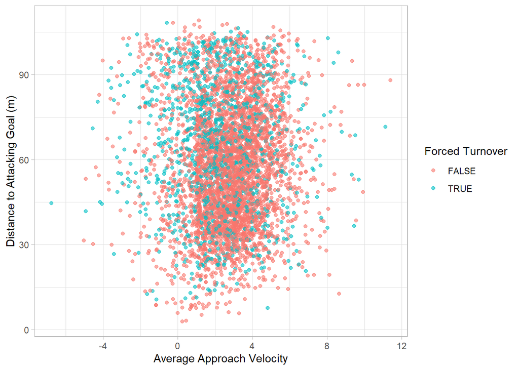

```r
ggplot(pressing_data, aes(x = avg_approach_velocity, y = dist_to_attacking_goal,
                         color = forced_turnover_within_5s)) +
  geom_point(alpha = 0.6) +
  labs(
    x = "Average Approach Velocity",
    y = "Distance to Attacking Goal (m)",
    color = "Forced Turnover",
  )
```

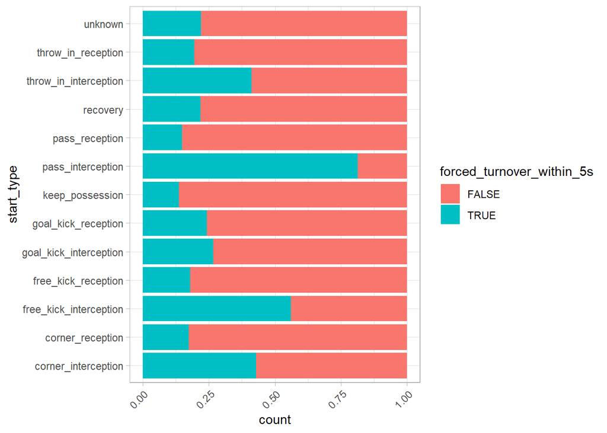

```r
ggplot(pressing_data, aes(start_type, fill = forced_turnover_within_5s)) +
  geom_bar(position = "fill") +
  coord_flip() +
  theme(axis.text.x = element_text(angle = 45, hjust = 1))
```

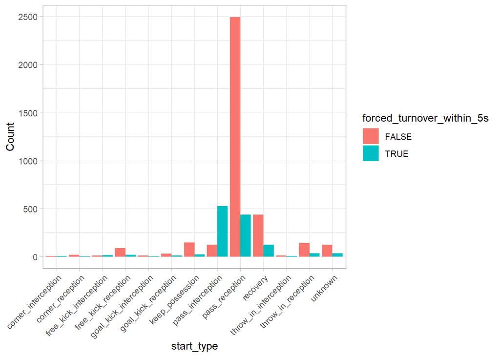

```r
ggplot(pressing_data, aes(start_type, fill = forced_turnover_within_5s)) +
  geom_bar(position = "dodge") +
  labs(y = "Count") +
  theme(axis.text.x = element_text(angle = 45, hjust = 1))
```

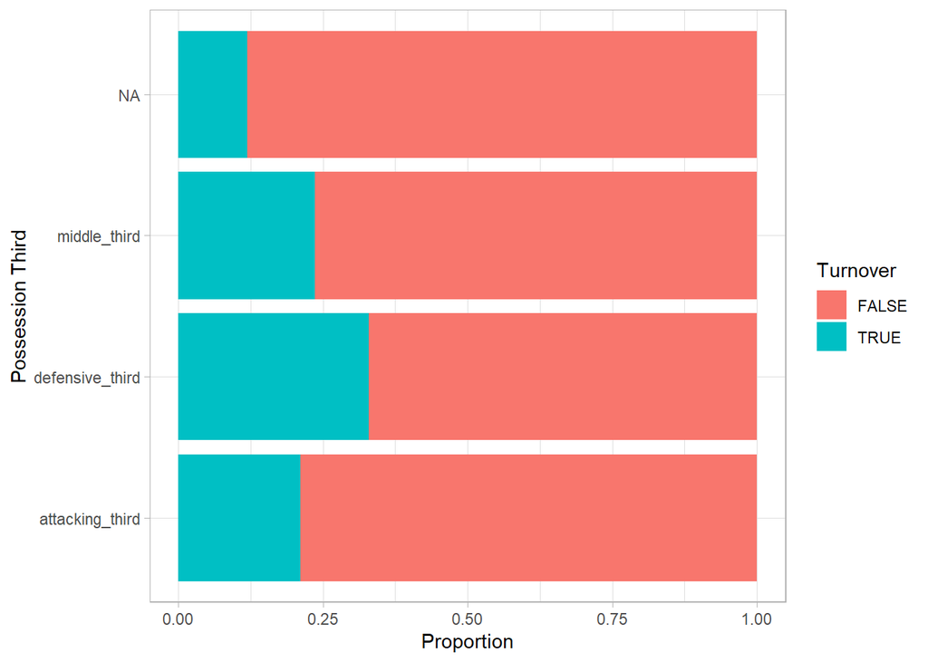

```r
ggplot(pressing_data, aes(poss_third_start, fill = forced_turnover_within_5s)) +
  geom_bar(position = "fill") +
  coord_flip() +
  labs(
    y = "Proportion",
    x = "Possession Third",
    fill = "Turnover"
  )
```

## Build a model with `tidymodels`

Create training and testing sets

```r
set.seed(123)
pressing_split <- initial_split(pressing_data, strata = forced_turnover_within_5s)
pressing_train <- training(pressing_split)
pressing_test <- testing(pressing_split)
```

### XGBoost Model

```r
xgb_spec <- boost_tree(
  trees = 1000,
  tree_depth = tune(),
  min_n = tune(),
  loss_reduction = tune(),
  sample_size = tune(),
  mtry = tune(),
  learn_rate = tune()
) |>
  set_engine("xgboost") |>
  set_mode("classification")

xgb_spec
```

```
## Boosted Tree Model Specification (classification)
##
## Main Arguments:
##   mtry = tune()
##   trees = 1000
##   min_n = tune()
##   tree_depth = tune()
##   learn_rate = tune()
##   loss_reduction = tune()
##   sample_size = tune()
##
## Computational engine: xgboost
```

We’re tuning 6 hyperparameters to find the optimal model configuration. This will help prevent overfitting while maximizing predictive performance.

### Hyperparameter grid

```r
xgb_grid <- grid_space_filling(
  tree_depth(),
  min_n(),
  loss_reduction(),
  sample_size = sample_prop(),
  finalize(mtry(), pressing_train),
  learn_rate(),
  size = 20 # you can change this number

)

xgb_grid
```

```
## # A tibble: 20 × 6
##    tree_depth min_n loss_reduction sample_size  mtry learn_rate
##         <int> <int>          <dbl>       <dbl> <int>      <dbl>
##  1          1    24       1.13e- 4       0.763    25   2.07e- 7
##  2          1    10       4.55e- 4       0.716     3   7.85e- 9
##  3          2    34       4.03e-10       0.526     6   4.83e- 5
##  4          2    22       1.95e+ 0       0.668     9   1   e- 1
##  5          3    36       4.83e- 1       0.242    11   2.34e- 8
##  6          3     2       6.54e- 9       0.621    16   3.79e- 3
##  7          4    16       1.62e- 9       0.195    17   2.98e-10
##  8          4     4       7.85e+ 0       0.289    20   6.16e- 7
##  9          5    28       6.95e- 6       0.147    24   1.13e- 2
## 10          5    12       2.80e- 5       0.1       2   1.44e- 4
## 11          6    38       2.98e- 2       0.953     7   6.95e- 8
## 12          7    20       1   e-10       0.905    14   2.64e- 9
## 13          8    32       1.73e- 6       0.858    22   3.36e- 2
## 14          9     6       1.20e- 1       1        18   5.46e- 6
## 15         10    30       7.39e- 3       0.574    27   8.86e-10
## 16         11    18       4.28e- 7       0.811     1   1.27e- 3
## 17         12    14       1.83e- 3       0.479     5   1   e-10
## 18         13    40       2.64e- 8       0.337    10   1.83e- 6
## 19         14    26       3.16e+ 1       0.432    13   4.28e- 4
## 20         15     8       1.06e- 7       0.384    21   1.62e- 5
```

### Workflow Setup

```r
xgb_wf <- workflow() |>
  add_formula(forced_turnover_within_5s ~ .) |>
  add_model(xgb_spec)

xgb_wf
```

```
## ══ Workflow ════════════════════════════════════════════════════════════════════
## Preprocessor: Formula
## Model: boost_tree()
##
## ── Preprocessor ────────────────────────────────────────────────────────────────
## forced_turnover_within_5s ~ .
##
## ── Model ───────────────────────────────────────────────────────────────────────
## Boosted Tree Model Specification (classification)
##
## Main Arguments:
##   mtry = tune()
##   trees = 1000
##   min_n = tune()
##   tree_depth = tune()
##   learn_rate = tune()
##   loss_reduction = tune()
##   sample_size = tune()
##
## Computational engine: xgboost
```

### Cross-Validation Folds

10-fold cross-validation

```r
pressing_folds <- vfold_cv(pressing_train, strata = forced_turnover_within_5s)

pressing_folds
```

```
## #  10-fold cross-validation using stratification
## # A tibble: 10 × 2
##    splits             id
##    <list>             <chr>
##  1 <split [3288/367]> Fold01
##  2 <split [3289/366]> Fold02
##  3 <split [3289/366]> Fold03
##  4 <split [3289/366]> Fold04
##  5 <split [3290/365]> Fold05
##  6 <split [3290/365]> Fold06
##  7 <split [3290/365]> Fold07
##  8 <split [3290/365]> Fold08
##  9 <split [3290/365]> Fold09
## 10 <split [3290/365]> Fold10
```

### Hyperparamter tuning

Now we’ll train our XGBoost model with all 20 hyperparameter combinations across our 10 cross-validation folds. This will take a few minutes to run.

```r
doParallel::registerDoParallel() # to make this process faster

set.seed(456)
tic()
xgb_res <- tune_grid(
  xgb_wf,
  resamples = pressing_folds,
  grid = xgb_grid,
  control = control_grid(save_pred = TRUE) # save for roc curve
)
toc()
```

```
## 654.91 sec elapsed
```

```r
xgb_res
```

```
## # Tuning results
## # 10-fold cross-validation using stratification
## # A tibble: 10 × 5
##    splits             id     .metrics           .notes           .predictions
##    <list>             <chr>  <list>             <list>           <list>
##  1 <split [3288/367]> Fold01 <tibble [60 × 10]> <tibble [0 × 3]> <tibble>
##  2 <split [3289/366]> Fold02 <tibble [60 × 10]> <tibble [0 × 3]> <tibble>
##  3 <split [3289/366]> Fold03 <tibble [60 × 10]> <tibble [0 × 3]> <tibble>
##  4 <split [3289/366]> Fold04 <tibble [60 × 10]> <tibble [0 × 3]> <tibble>
##  5 <split [3290/365]> Fold05 <tibble [60 × 10]> <tibble [0 × 3]> <tibble>
##  6 <split [3290/365]> Fold06 <tibble [60 × 10]> <tibble [0 × 3]> <tibble>
##  7 <split [3290/365]> Fold07 <tibble [60 × 10]> <tibble [0 × 3]> <tibble>
##  8 <split [3290/365]> Fold08 <tibble [60 × 10]> <tibble [0 × 3]> <tibble>
##  9 <split [3290/365]> Fold09 <tibble [60 × 10]> <tibble [0 × 3]> <tibble>
## 10 <split [3290/365]> Fold10 <tibble [60 × 10]> <tibble [0 × 3]> <tibble>
```

**Explain:** We trained 200 models (20 hyperparameter combinations × 10 folds) and evaluated each one. The save_pred = TRUE option stores all the predictions so we can create detailed performance plots later.

## Explore Results

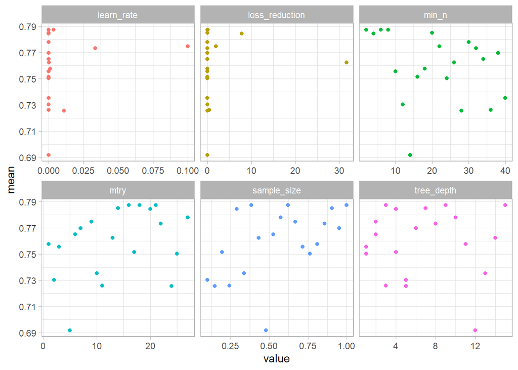

```r
xgb_res |>
  collect_metrics() |>
  filter(.metric == "roc_auc") |>
  select(mean, mtry:sample_size) |>
  pivot_longer(mtry:sample_size,
               names_to = "parameter",
               values_to = "value") |>
  ggplot(aes(value, mean, color = parameter)) +
  geom_point(show.legend = FALSE) +
  facet_wrap(~parameter, scales = "free_x")
```

## Best Performing Model

```r
show_best(xgb_res, metric = "roc_auc")
```

```
## # A tibble: 5 × 12
##    mtry min_n tree_depth    learn_rate loss_reduction sample_size .metric
##   <int> <int>      <int>         <dbl>          <dbl>       <dbl> <chr>
## 1    18     6          9 0.00000546     0.120               1     roc_auc
## 2    16     2          3 0.00379        0.00000000654       0.621 roc_auc
## 3    21     8         15 0.0000162      0.000000106         0.384 roc_auc
## 4    14    20          7 0.00000000264  0.0000000001        0.905 roc_auc
## 5    20     4          4 0.000000616    7.85                0.289 roc_auc
## # ℹ 5 more variables: .estimator <chr>, mean <dbl>, n <int>, std_err <dbl>,
## #   .config <chr>
```

```r
best_auc <- select_best(xgb_res, metric = "roc_auc")

best_auc
```

```
## # A tibble: 1 × 7
##    mtry min_n tree_depth learn_rate loss_reduction sample_size .config
##   <int> <int>      <int>      <dbl>          <dbl>       <dbl> <chr>
## 1    18     6          9 0.00000546          0.120           1 Preprocessor1_Mo…
```

### Finalize workflow

```r
final_xgb <- finalize_workflow(xgb_wf, best_auc )

final_xgb
```

```
## ══ Workflow ════════════════════════════════════════════════════════════════════
## Preprocessor: Formula
## Model: boost_tree()
##
## ── Preprocessor ────────────────────────────────────────────────────────────────
## forced_turnover_within_5s ~ .
##
## ── Model ───────────────────────────────────────────────────────────────────────
## Boosted Tree Model Specification (classification)
##
## Main Arguments:
##   mtry = 18
##   trees = 1000
##   min_n = 6
##   tree_depth = 9
##   learn_rate = 5.45559478116851e-06
##   loss_reduction = 0.119935394620924
##   sample_size = 1
##
## Computational engine: xgboost
```

## Variable Importance

Which features are most important for predicting pressing success?

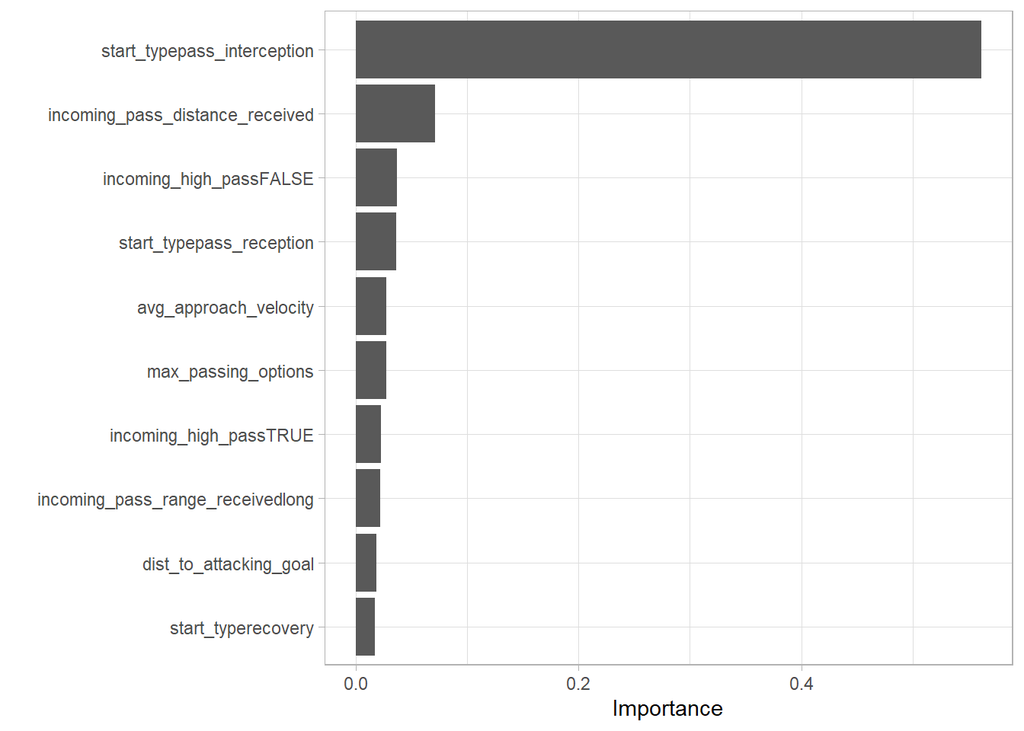

```r
library(vip)

final_xgb |>
  fit(data = pressing_train) |>
  extract_fit_parsnip() |>
  vip()
```

## Final Evaluation

Now let’s see how our model performs on unseen data:

```r
final_res <- last_fit(final_xgb, pressing_split)

final_res |>
  collect_metrics()
```

```
## # A tibble: 3 × 4
##   .metric     .estimator .estimate .config
##   <chr>       <chr>          <dbl> <chr>
## 1 accuracy    binary         0.821 Preprocessor1_Model1
## 2 roc_auc     binary         0.782 Preprocessor1_Model1
## 3 brier_class binary         0.249 Preprocessor1_Model1
```

### Confusion matrix

```r
final_res |>
  collect_predictions() |>
  conf_mat(forced_turnover_within_5s, .pred_class)
```

```
##           Truth
## Prediction FALSE TRUE
##      FALSE   870  179
##      TRUE     39  132
```

### ROC cuve

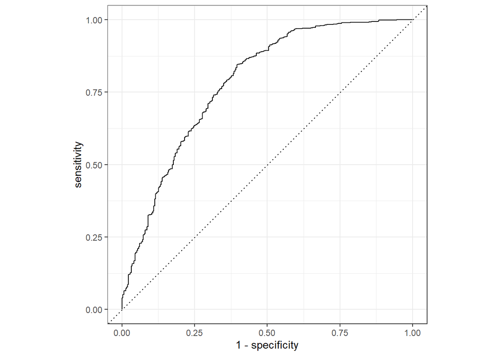

```r
final_res |>
  collect_predictions() |>
  roc_curve(forced_turnover_within_5s, .pred_FALSE) |>
  autoplot()
```

## Next steps

Now that we have an XGBoost model, we plan to compare it with other models. e.g logistic, random forest, lightGBM